# $Project: Investigate\, a\, Dataset$

```
Age Group  (-0.08, 16]  (16, 32]  (32, 48]  (48, 64]  (64, 80]  All
Survived
0                   45       344       111        39        10  549
1                   55       181        75        30         1  342
All                100       525       186        69        11  891
```

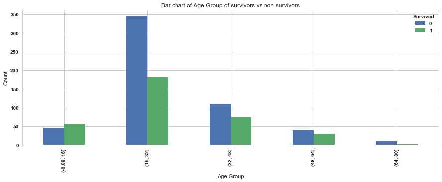

```python
# cross-tabulation of Age group and Survived
print(pd.crosstab(titanic_dataset["Age Group"], titanic_dataset["Survived"], margins=True).transpose())
pd.crosstab(titanic_dataset["Age Group"], titanic_dataset["Survived"]).plot.bar(stacked=False, figsize=(15,5))
plt.ylabel("Count")
plt.title("Bar chart of Age Group of survivors vs non-survivors")
```

*The next plot displays the proportion of survivors for each age group and builds on top of the previous plot.*

```
Age Group  (-0.08, 16]  (16, 32]  (32, 48]  (48, 64]  (64, 80]
Survived          0.55  0.344762  0.403226  0.434783  0.090909
```

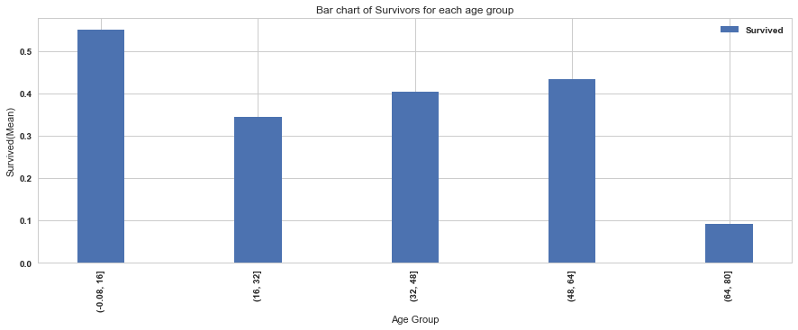

```python
# Proportion of survivors in each range
print(titanic_dataset[['Age Group', 'Survived']].groupby(['Age Group']).mean().transpose())
titanic_dataset[['Age Group', 'Survived']].groupby(['Age Group']).mean().plot.bar(stacked=False, figsize=(15, 5), width=.3)
plt.ylabel("Survived(Mean)")
plt.title("Bar chart of Survivors for each age group")
```

*Proceeding on to comparing Age group with Sex. The next tab shows the number of female to male count in each age group. This comparison is clearly displayed through the bar chart below.*

**Quick Numbers:**  
*• 49 females to 51 males in 0 - 16 age group*  
*• Most number of females (174) in 16 - 32 age group*  
*• Most number of males (351) in 16 - 32 age group*  
*• 0 females to 11 males in 64 - 80 age group*

```
Age Group  (-0.08, 16]  (16, 32]  (32, 48]  (48, 64]  (64, 80]  All
Sex
female              49       174        67        24         0  314
male                51       351       119        45        11  577
All                100       525       186        69        11  891
```

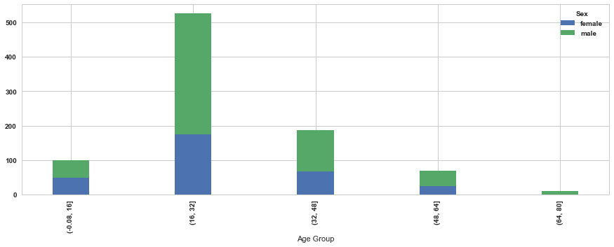

```python
print(pd.crosstab(titanic_dataset["Age Group"], titanic_dataset["Sex"], margins=True).transpose())
pd.crosstab(titanic_dataset["Age Group"], titanic_dataset["Sex"]).plot.bar(stacked=True,figsize=(15,5), width=.3)
```

*The next tab shows the proportion of female and male survivors for each age group.*

```
Survived                   0         1
Age Group   Sex
(-0.08, 16] female  0.326531  0.673469
            male    0.568627  0.431373
(16, 32]    female  0.281609  0.718391
            male    0.840456  0.159544
(32, 48]    female  0.208955  0.791045
            male    0.815126  0.184874
(48, 64]    female  0.083333  0.916667
            male    0.822222  0.177778
(64, 80]    female       NaN       NaN
            male    0.909091  0.090909
```

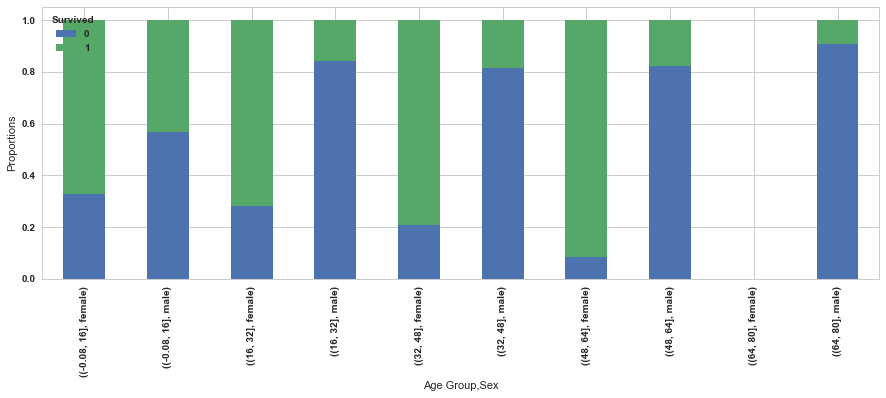

```python
#print(pd.crosstab((titanic_dataset["Age Group"], titanic_dataset["Sex"]), titanic_dataset["Survived"],margins=True))
tabA = pd.crosstab((titanic_dataset["Age Group"], titanic_dataset["Sex"]), titanic_dataset["Survived"])
tabA.div(tabA.sum(1).astype(float), axis=0).plot(kind="bar", stacked=True, figsize=(15, 5))
plt.ylabel("Proportions")
print(tabA.div(tabA.sum(1).astype(float), axis=0))
```

*These figures show the data from other angles, but it is still hard for me to connect the dots regarding age being a factor in survival. One assumption this analysis does seem to support however, is about younger males having a better chance of survival than older males, and older females having a better chance of survival than younger females.*

*The results of this section can be summarized in the following way:*

*• A passenger below 16 years showed a better chance of survival than others on board*  
*• This was probably the worst time to be a senior citizen as passengers between 64 - 80 showed the worst chance of survival*  
*• Males below 16 years showed better chances of survival than older males*  
*• Females between 48 - 64 showed the best chance of survival*

### *Fare*

*In this section I'll investigate Fare. This should lead to some interesting points since Fare showed a positive correlation with Survived in the correaltion matrix. The question I want to answer in this section is:*  
**• Did passengers who paid higher fares had higher chances of survival?**

*The Fare column does not say which currency the fare was paid in. I am guessing it is in Pounds, since the ship belonged to the White Star Line, a prominent British shipping company. But I'll leave it as is since there is nothing mentioned about currency in the dataset.*

*I'll begin by plotting a line chart.*

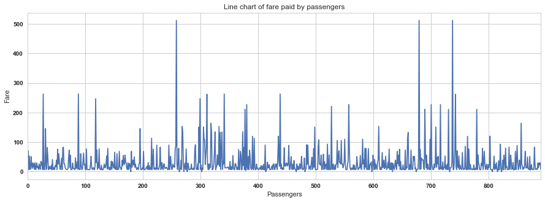

```python
# line plot
titanic_dataset['Fare'].astype(int).plot(kind='line', figsize=(15,5))
plt.xlabel("Passengers")
plt.ylabel("Fare")
plt.title("Line chart of fare paid by passengers")
```

*The line chart above shows a nice visual interpretation of how much fare each passenger paid to be on board. Three huge spikes in fare above 500, particularly stand out. Besides that, there were 50 counts in which passengers paid 100 or more. On the other hand, there were 336 passengers who paid less than 10.*

*The plot below compares the mean fare of survivors with non-survivors. Quite clearly, surviving passengers paid a higher mean fare (48) than non surviving passengers (22). This leads to an early indication that high paying customers might have had better chances of survival.*

```
Mean fare paid by non survivors 21.69
Mean fare paid by survivors 47.99
```

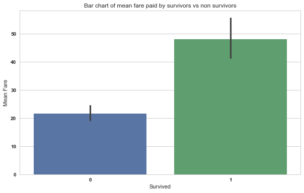

```python
# convert from float to int
titanic_dataset['Fare'] = titanic_dataset['Fare'].astype(int)
# get fare for survived & deceased passengers
fare_not_surv = titanic_dataset["Fare"][titanic_dataset["Survived"] == 0]
fare_surv = titanic_dataset["Fare"][titanic_dataset["Survived"] == 1]

# plotting a bar chart of mean fare paid by survivors and non survivors
plt.subplots(1, figsize=(10, 6))
sns.barplot(data=[fare_not_surv, fare_surv])
plt.xlabel("Survived")
plt.ylabel("Mean Fare")
plt.title("Bar chart of mean fare paid by survivors vs non survivors")
print("Mean fare paid by non survivors {}\nMean fare paid by survivors {}".format(round(fare_not_surv.mean(), 2), round(fare_surv.mean(), 2)))
```

*To further investigate a connection between Fare and Survived, I will break Fare into 4 price ranges and create a new column called Price Band. These ranges will be between (0, 7), (7, 14), (14, 31), (31, 512). This will allow me to compute porportion of survivors for each category.*

```python
# creating a new column called Price Band containing fare prices in 4 categories
# (0, 7), (7, 14), (14, 31), (31, 512)
titanic_dataset["Price Band"] = pd.qcut(titanic_dataset["Fare"],4)
```

```python
# Categories of price bands
titanic_dataset[["Price Band", 'Survived']].groupby(["Price Band"], as_index=False).mean().sort_values(by="Price Band", ascending=True).drop("Survived", axis=1).T
```

|  | 0 | 1 | 2 | 3 |
| --- | --- | --- | --- | --- |
| Price Band | [0, 7] | (7, 14] | (14, 31] | (31, 512] |

```
Price Band  [0, 7]  (7, 14]  (14, 31]  (31, 512]  All
Survived
0              189      154       121         85  549
1               52       62       102        126  342
All            241      216       223        211  891
```

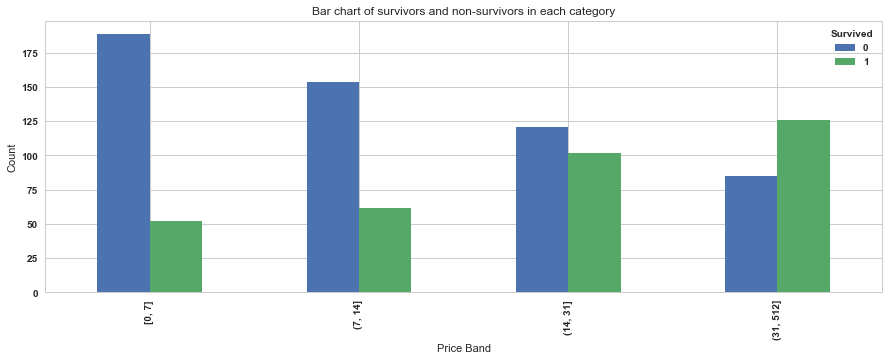

```python
# plotting survivors vs non survivors for each category of Fare
print(pd.crosstab(titanic_dataset["Price Band"], titanic_dataset["Survived"], margins=True).transpose())
pd.crosstab(titanic_dataset["Price Band"], titanic_dataset["Survived"]).plot.bar(figsize=(15, 5))
plt.ylabel("Count")
plt.title("Bar chart of survivors and non-survivors in each category")
```

```
                   0         1         2          3
Price Band    [0, 7]   (7, 14]  (14, 31]  (31, 512]
Survived    0.215768  0.287037  0.457399   0.597156
```

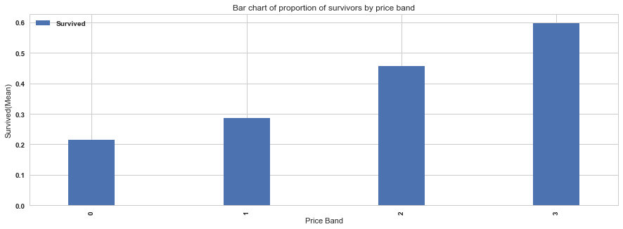

```python
# plotting bar chart of surviving passengers for each category
price_band = titanic_dataset[["Price Band", 'Survived']].groupby(["Price Band"], as_index=False).mean()
print(price_band.T)
price_band.plot.bar(figsize=(15, 5), width=.3)
plt.xlabel("Price Band")
plt.ylabel("Survived(Mean)")
plt.title("Bar chart of proportion of survivors by price band")
```

*This result is quite decisive. The bar chart makes it pretty clear to visualize that survival rate increases linearly as fare prices increase. I can summarize this section by saying that fare could have been one of the vital factors in survival of a passenger on board. In other words, rich passengers might have had better chances of survival than not so rich ones.*

### *Pclass*

*Pclass is next in the investigation. This is another variable that showed signs of correlation with Survived in the correlation matrix. Examining Pclass could answer question like:*  
**• How many passengers where in each class?**  
**• How many passengers survived in each class?**  
**• Did Pclass affect survival?**

*I'am going to quickly check and plot mean fares for each class.*

```
Pclass         1          2          3
Fare    83.74537  20.456522  13.173116
```

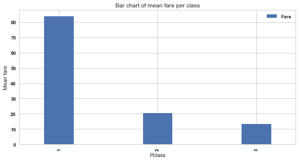

```python
# checking mean fare paid per class
print(titanic_dataset[["Pclass", "Fare"]].groupby("Pclass").mean().T)
titanic_dataset[["Pclass", "Fare"]].groupby("Pclass").mean().plot.bar(figsize=(10, 5),width=.3)
plt.ylabel("Mean fare")
plt.title("Bar chart of mean fare per class")
```

*Well, no surprises there! Third class had the lowest mean fare of 13, first class had the highest mean fare of 84, while second class had a mean fare of 21.*

*Next chart shows the proportion of passengers per class. Surprisingly, second class had the least number of passengers on board (184). On the other hand, more than 50% passengers on board were travelling third class.*

```
3    0.551066
1    0.242424
2    0.206510
Name: Pclass, dtype: float64
```

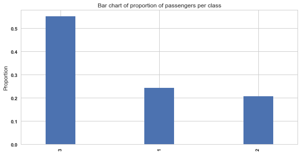

```python
pclass_proportion = titanic_dataset["Pclass"].value_counts()
print(pclass_proportion.div(pclass_proportion.sum(), axis=0))
pclass_proportion.div(pclass_proportion.sum(), axis=0).plot.bar(figsize=(10, 5), width=.3)
plt.ylabel("Proportion")
plt.title("Bar chart of proportion of passengers per class")
```

*Next, I am going to check proportion of male and female survivors vs non-survivors for each class.*

```
Pclass           1                   2                3
Sex         female      male    female      male female      male
Survived
0         0.031915  0.631148  0.078947  0.842593    0.5  0.864553
1         0.968085  0.368852  0.921053  0.157407    0.5  0.135447
```

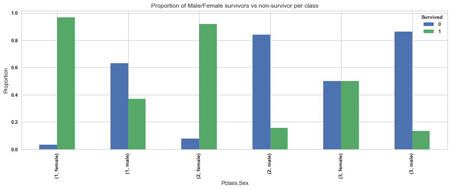

```python
# plotting proportion of male/female survivors vs non-survivora per class
pclass_proportions = pd.crosstab((titanic_dataset["Pclass"], titanic_dataset["Sex"]), titanic_dataset["Survived"])
pclass_proportions.div(pclass_proportions.sum(1),axis=0).plot.bar(figsize=(15, 5))
plt.ylabel("Proportion")
plt.title("Proportion of Male/Female survivors vs non-survivor per class")
print(pclass_proportions.div(pclass_proportions.sum(1),axis=0).T)
```

*The proportions in each class are nicely visualized by the chart and some kind of trend is begining to emerge. 97% females vs 37% males survived in the first class. This fell down to 50% females vs 14% males surviving in the third class.*

*The next chart drives the point home and establishes a very clear trend that as class increased survival rate decreased.*

```
   Pclass  Survived
0       1  0.629630
1       2  0.472826
2       3  0.242363
```

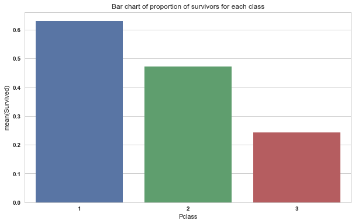

```python
class_survived = titanic_dataset[["Pclass", "Survived"]].groupby(["Pclass"], as_index=False).mean()
print(class_survived)
plt.subplots(figsize=(10,6))
sns.barplot(x="Pclass", y="Survived", data=class_survived)
plt.title("Bar chart of proportion of survivors for each class")
```

```python
# checking correlation between Pclass and Fare
pclass_correlation = titanic_dataset.corr()["Pclass"]
pclass_correlation["Fare"]
```

```
-0.55055310560232784
```

*372 out of 491 people died in the third class section of the Titanic; this is a meagre 24% survival rate. On the other hand, 62% passengers survived in the first class. This raises all kinds of questions in my head regarding the ships design, safety measures, even the shipping company's business ethics, but those are outside the scope of this investigation. I am assuming, first class travellers might have had their cabins closer to the deck, making them reach the lifeboats earlier than others, allowing them to be saved first. Whatever the reasons were, they were definitely in favour of first class passengers.*

*In closing, I can say that Pclass could have been another important factor in survival of people on board. It also reinforces inferences made in the previous section that rich folks might have had greater chances of survival.*

### *Embarked*

*The Embarked column contains information regarding the three ports of embrakation: Southhampton, Cherbourg and Queenstown. Analyzing this feature could answer questions like:*  
**• How many passengers embarked from each port?**  
**• What was the proportions of passengers travelling first, second and third class from each port?**  
**• What was the survival rate for each port?**

```
S    0.724409
C    0.188976
Q    0.086614
Name: Embarked, dtype: float64
```

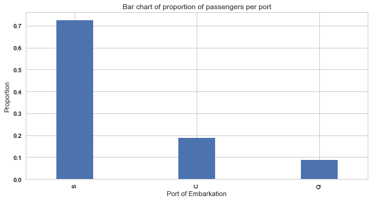

```python
# plotting proportion of passengers for each port of embarkation

#print(titanic_dataset["Embarked"].value_counts())
embarked_passenger_proportion = titanic_dataset["Embarked"].value_counts()
embarked_passenger_proportion.div(embarked_passenger_proportion.sum(), axis=0).plot.bar(figsize=(10, 5), width=.3)
plt.xlabel("Port of Embarkation")
plt.ylabel("Proportion")
plt.title("Bar chart of proportion of passengers per port")
print(embarked_passenger_proportion.div(embarked_passenger_proportion.sum(), axis=0))
```

*72% passengers embarked from Southhampton. This seems natural since Southhampton was the starting point of the voyage. 19% passengers boarded from Cherbourg and only 8% passengers embarked from Queenstown.*

*The next chart shows a class-wise proportion of passengers for each port. There are some figures in particular I found interesting:*  
*1) 51% passengers from Cherbourg travelled first class. Port with highest number of first class travellers.*  
*2) 54% passengers from Southhampton travelled third class.*  
*3) While only 77 passengers boarded from Queenstown 94% of them travelled third class.*

```
Embarked         C         Q         S
Pclass
1         0.505952  0.025974  0.197205
2         0.101190  0.038961  0.254658
3         0.392857  0.935065  0.548137
```

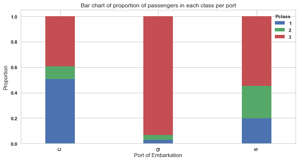

```python
# plotting class wise porportions
embarked_pclass_proportions = pd.crosstab(titanic_dataset["Embarked"], titanic_dataset["Pclass"])
compute_proportions = embarked_pclass_proportions.div(embarked_pclass_proportions.sum(1), axis=0)
compute_proportions.plot.bar(stacked=True, figsize=(10,5), width=.3)
print(compute_proportions.T)
plt.xlabel('Port of Embarkation')
plt.ylabel('Proportion')
plt.title("Bar chart of proportion of passengers in each class per port")
```

*Before I plot the next chart, I'll impute the missing embarked values. First, I'll check where the missing entries are.*

```python
# Checking for missing entries
missing_Embarked = titanic_dataset[titanic_dataset["Embarked"].isnull()]
missing_Embarked
```

|  | PassengerId | Survived | Pclass | Name | Sex | Age | SibSp | Parch | Ticket | Fare | Cabin | Embarked | Title | Age Group | Price Band |
| --- | --- | --- | --- | --- | --- | --- | --- | --- | --- | --- | --- | --- | --- | --- | --- |
| 61 | 62 | 1 | 1 | Icard, Miss. Amelie | female | 38 | 0 | 0 | 113572 | 80 | B28 | NaN | Miss | (32, 48] | (31, 512] |
| 829 | 830 | 1 | 1 | Stone, Mrs. George Nelson (Martha Evelyn) | female | 62 | 0 | 0 | 113572 | 80 | B28 | NaN | Mrs | (48, 64] | (31, 512] |

*Here are my observations about the entries:*  
*• Both passengers were first class travellers*  
*• Both were females*  
*• Both survived*  
*• Both paid a fare of 80*

*Based on these observations, I'll check the statistics for female passenger who travelled first class and survived.*

```python
# checking descriptive statistics
titanic_dataset[(titanic_dataset["Survived"]==1) & (titanic_dataset["Sex"]=="female") & (titanic_dataset["Pclass"]==1)]\
[["Fare", "Embarked"]].groupby("Embarked").describe().loc["C"].T
```

|  | count | mean | std | min | 25% | 50% | 75% | max |
| --- | --- | --- | --- | --- | --- | --- | --- | --- |
| Fare | 42.0 | 117.261905 | 88.591983 | 27.0 | 69.5 | 83.0 | 134.0 | 512.0 |

```python
# imputing missing values with "C". Because C median Fare is 83 which is close to the Fare
# of two passengers with Nan values.
titanic_dataset["Embarked"] = titanic_dataset["Embarked"].fillna("C")
print("Number of null values remaining in this column: {}".format(titanic_dataset["Embarked"].isnull().sum()))
```

```
Number of null values remaining in this column: 0
```

*The last plot shows the number of survivers for each port. Cherbourg had the highest percentage of survivers with 56%, Queenstown was next with 39%, and Southhampton had the least percentage of surviving passengers with 34%.*

```
  Embarked  Survived
0        C  0.558824
1        Q  0.389610
2        S  0.336957
```

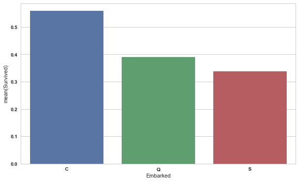

```python
# plotting survived proportion for survived
embarked_survived = titanic_dataset[["Embarked", "Survived"]].groupby(["Embarked"], as_index=False).mean()
print(embarked_survived)
plt.subplots(figsize=(10,6))
sns.barplot(x="Embarked", y="Survived", data=embarked_survived)
```

*More than 50% passengers travelling from Cherbourg survived. 39% from Queenstown and 34% from Southhampton survived. To conclude this section, I can say that if a passenger embarked from Cherbourg, she might have had a better chance of survival than passengers embarking from other destinations.*

### *Sibsp and Parch*

*SibSp and Parch are features that can be investigated together. The questions I plan to ask through this analysis are:*  
*• What was the SibSp survival rate for all sizes?*  
*• What was the Parch survival rate for all sizes?*

*I am going to start by plotting a bar chart that shows proportions of SibSp survivors*

```
                 0         1         2     3         4    5    6
SibSp     0.000000  1.000000  2.000000  3.00  4.000000  5.0  8.0
Survived  0.345395  0.535885  0.464286  0.25  0.166667  0.0  0.0
```

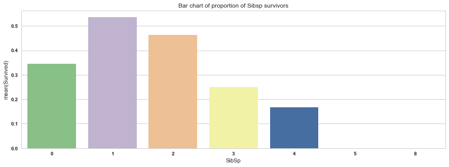

```python
sibsp = titanic_dataset[["SibSp", "Survived"]].groupby(["SibSp"], as_index=False).mean()
print(sibsp.transpose())
plt.subplots(1, figsize=(15,5))
sns.barplot(x="SibSp", y="Survived", data=sibsp, palette="Accent")
plt.title("Bar chart of proportion of Sibsp survivors")
```

*The bar chart makes it easy to visualize the different proportions. Passengers with 1 Sibling /Spouse on board had a 54% survival rate. Passengers with 2 Siblings/Spouses had the next best survival rate of 46%. Passengers having Siblings/Spouses greater than 4 did not survive at all.*

*The chart shows the proportion of Parch Survivors.*

```
                 0         1    2    3    4    5    6
Parch     0.000000  1.000000  2.0  3.0  4.0  5.0  6.0
Survived  0.343658  0.550847  0.5  0.6  0.0  0.2  0.0
```

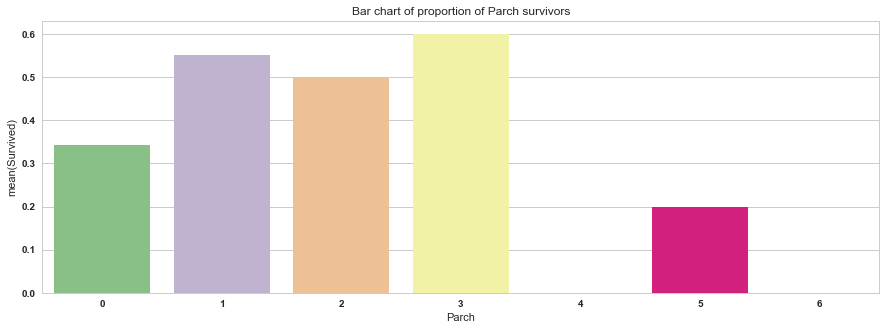

```python
parch = titanic_dataset[["Parch", "Survived"]].groupby(["Parch"], as_index=False).mean()
print(parch.transpose())
plt.subplots(1, figsize=(15,5))
sns.barplot(x="Parch", y="Survived", data=parch, palette="Accent")
plt.title("Bar chart of proportion of Parch survivors")
```

*This chart again shows that passengers with bigger family size, specifically a family size greater than 3, did not have a great chance of survival.*

### *Further Analysis*

*There is one last thing left to do before I present my conclusions. I want to check correlation of categorical data with the numerical data. To do so, I will substitute the entire dataset with ordinal values. Once I have converted all values to ordinal numbers, I will test their correlation with one another through the correlation matrix.*

```python
# converting Embarked
titanic_dataset["Embarked Ordinal"] = titanic_dataset["Embarked"]
for data in titanic_dataset:
    if data == "Embarked":
         titanic_dataset["Embarked Ordinal"] = titanic_dataset["Embarked Ordinal"].map({"S": 0, "C": 1, "Q": 2})
```

```python
# converting Fare
titanic_dataset["Fare Ordinal"] =  titanic_dataset["Fare"]
for values in titanic_dataset:
    titanic_dataset.loc[titanic_dataset["Fare"] <= 7, "Fare Ordinal"] = 0
    titanic_dataset.loc[(titanic_dataset['Fare'] > 7) & (titanic_dataset['Fare'] <= 14), "Fare Ordinal"] = 1
    titanic_dataset.loc[(titanic_dataset['Fare'] > 14) & (titanic_dataset['Fare'] <= 31), "Fare Ordinal"] = 2
    titanic_dataset.loc[titanic_dataset['Fare'] > 31, "Fare Ordinal"] = 3
```

```python
# converting Age
titanic_dataset["Age Ordinal"]= titanic_dataset["Age"]
for age in titanic_dataset:
    titanic_dataset.loc[titanic_dataset["Age"] <= 16, "Age Ordinal"] = 0
    titanic_dataset.loc[(titanic_dataset["Age"] > 16) & (titanic_dataset["Age"] <= 32), "Age Ordinal"] = 1
    titanic_dataset.loc[(titanic_dataset["Age"] > 32) & (titanic_dataset["Age"] <= 48), "Age Ordinal"] = 2
    titanic_dataset.loc[(titanic_dataset["Age"] > 48) & (titanic_dataset["Age"] <= 64), "Age Ordinal"] = 3
    titanic_dataset.loc[titanic_dataset["Age"] > 64, "Age Ordinal"] = 4
```

```python
# converting Sex
titanic_dataset["Gender Ordinal"] = titanic_dataset["Sex"]
for sex in titanic_dataset:
    if sex == "Sex":
        titanic_dataset["Gender Ordinal"] = titanic_dataset["Gender Ordinal"].map({"female":0, "male":1})
```

```python
# creating a new variable called Family Size by adding SibSp and Parch columns
titanic_dataset["Family Size"] = titanic_dataset["SibSp"] + titanic_dataset["Parch"]
```

```python
# creating a copy of the dataset
new_titanic_data = titanic_dataset.copy()
```

```python
# dropping columns I dont need
new_titanic_data.drop(["PassengerId", "Sex", "Age", "Embarked", "Age Group", "Price Band", "Title", "Name", "Ticket", "SibSp", "Parch", "Fare", "Cabin"],axis=1, inplace=True)
```

```python
# previewing the new dataset
new_titanic_data.head()
```

|  | Survived | Pclass | Embarked Ordinal | Fare Ordinal | Age Ordinal | Gender Ordinal | Family Size |
| --- | --- | --- | --- | --- | --- | --- | --- |
| 0 | 0 | 3 | 0 | 0 | 1 | 1 | 1 |
| 1 | 1 | 1 | 1 | 3 | 2 | 0 | 1 |
| 2 | 1 | 3 | 0 | 0 | 1 | 0 | 0 |
| 3 | 1 | 1 | 0 | 3 | 2 | 0 | 1 |
| 4 | 0 | 3 | 0 | 1 | 2 | 1 | 0 |

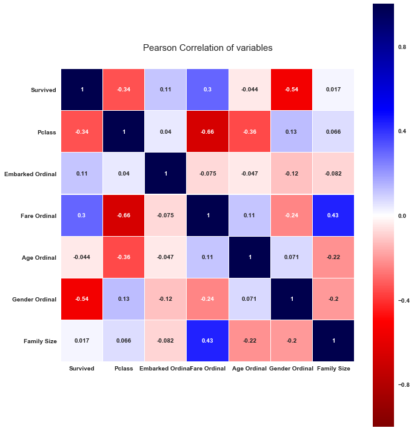

```python
# plotting correlations
colormap = plt.cm.seismic_r
plt.subplots(figsize=(10,10))
plt.title("Pearson Correlation of variables", y=1.05, size=15)
sns.heatmap(new_titanic_data.corr(), linewidths=0.1,vmax=1.0, square=True, cmap=colormap, linecolor='white', annot=True)
plt.tight_layout()
```

```python
# comparison of the new and old
new_correlation = new_titanic_data.corr()["Survived"].drop("Survived",axis=0)
old_correlation = titanic_dataset.corr()["Survived"].drop(["PassengerId", "Age Ordinal", "Gender Ordinal", "Family Size", "Fare Ordinal", "Embarked Ordinal"], axis=0)
print(new_correlation)
print("- "*20)
print(old_correlation)
```

```
Pclass             -0.338481
Embarked Ordinal    0.111203
Fare Ordinal        0.301792
Age Ordinal        -0.044492
Gender Ordinal     -0.543351
Family Size         0.016639
Name: Survived, dtype: float64
- - - - - - - - - - - - - - - - - - - -
Survived    1.000000
Pclass     -0.338481
Age        -0.064909
SibSp      -0.035322
Parch       0.081629
Fare        0.257482
Name: Survived, dtype: float64
```

*The new matrix shows correlation of variables with Survived that were not measured before. It confirms lot of inferences made perviously in this study, especially related to Sex, Pclass and Fare.*

### *Limitations*

*Considering that the size of the dataset was fairly small and almost all of the data was analyized using vectorized operations, the computational cost for analyzing this dataset was fairly low. Therefore, I did not find computational cost limiting my analysis in a meaningful way. While the dataset was small, the data within it was fairly rich. The sample size and number of variables were sufficient enough to let me perform a detailed analysis. Therefore, the data itself was not limiting.*

*However, one aspect of the data that I did find limiting, was the lack of information regarding all the missing values. I did not know why those values were missing. Was the missingness completely at random or were there other reasons? Because I was not sure why those values were missing I was not able to prepare a better model to impute missing values in the data. If I had known the cause of missingness, I would have made a better model for substituting missing values that would have led to a more robust analysis.*

### *Conclusion*

*What factors made it more likely for a person to survive on the Titanic? That was the question that kickstarted this investigation. I think, I have enough evidence to answer this question now. According to this analysis, there were three probable factors that could have affected survival.*

*1) Gender: could have been the most important factor in survival of passengers on board, in my opinion. The women and children first policy might have allowed for 74% survival rate for women compared to 19 % survival rate for men.*

*2) Pclass: revealed that there was a strong relationship between a passengers' survival and the class she was travelling in. 63% first class travellers survived compared to only 24% that travelled in the third class. This is, pretty much, a clear indication that Pclass might have been another factor in survival.*

*3) Fare: also revealed a strong relationship with survival. The higher a customer paid the better chances of survival she had.*